# FLIGHT DELAY VISUALIZATION & MODELING

## By Ravi Surdhar, Dec 2018

This notebook uses the 2015 Flight Delays Dataset from Kaggle, as well as the Iowa State University AWOS Download Service, and attempts to generate a model to predict flight delays and cancellations based on airport weather.

The tech stack includes Pandas, Seaborn, Matplotlib, Scikit-Learn, XGBoost, and TensorFlow. Topics explored include: identifying and fixing corrupted data, big data techniques and optimizations, web scraping, data visualization, and model selection and evaluation.

My conclusion from this project was that weather features, such as cloud ceiling, visibility, and precipitations, are poor predictors of flight delays and cancellations. Ultimately, I creted an XGBoost random forest model with a precision of of 0.84 but a recall of only 0.11. In other words, only 11% of the flights that were actually cancelled were predicted to be cancelled. However, 84% of the flights that the model predicted to be cancelled were actually cancelled. If I were to use this model operationally, I wouldn't rely on it as the sole source for predicting whether or not a flight would be cancelled, since it fails to catch 89% of flights that are cancelled. However, whenever it does predict a particular flight to be cancelled, I could rely on it to be correct and start implementing contingency solutions for getting passengers to their destination.

### Data Preprocessing

When imported into a Pandas dataframe using the default settings, the dataframe uses 2.6 GB of memory and contains 5819079 x 31 entries. Ultimately I reduced this to only 181.1 MB, a 93% reduction, using the following techniques:

1. Dropping columns that contained data irrelevant to predicting flight delays, such as flight number, aircraft registration number, flight distance, etc.
2. Dropping flights to or from airports with fewer than 5 flights per day (ie, dropping outlier airports).
3. Downcasting each column's datatype to the most memory efficent datatype. By default, Pandas will import numerical data as either int64 or float64, and strings as objects. Large memory savings can be realized by downcasting one-hot encoded columns (such as CANCELLED or DIVERTED) from an 8-bit int64 to a 2-bit uint8. Columns containing departure and arrival delay times must be stored as float32, since they contain NaN values (for flights which were cancelled). Finally, massive savings can be realized by converting string columns (such as AIRLINE, DEPARTURE AIRPORT, and DESTINATION AIRPORT) as categories. These columns are perfect candidates for conversion to category data types because they contain few unique values compared to how many times each unique value appears.

Finally, I discovered that all of the flights that occured in October had corrupted arrival and departure airport data. Every other month used a three-letter IATA airport code (such as SFO or JFK), but the flights for October used a five digit Department of Transportation code (such as 14747). I created a dictionary that contained DOT Code : IATA Code mappings, which I then used to convert all of the airports in the dataframe that contained DOT Codes to their IATA equivalent.

Code extracts from this section are below.

```python
airport_id = pd.read_csv('AIRPORT ID.csv')
airport_iata = pd.read_csv('AIRPORT IATA.csv')
airport_iata_id = pd.merge(airport_iata, airport_id, on='Description')
airport_iata_id.rename({'Code_x': 'IATA', 'Code_y': 'ID'}, axis=1, inplace=True)
airport_dictionary = airport_iata_id[['ID', 'IATA']].set_index('ID').to_dict()['IATA']
fixed_flights = corrupted_flights.replace({'ORIGIN_AIRPORT' : airport_dictionary,
                                            'DESTINATION_AIRPORT' : airport_dictionary})
```

```python
flights = pd.read_csv('flights_reduced.csv',
                      index_col=0,
                      dtype = {'AIRLINE': 'category',
                                'ORIGIN_AIRPORT': 'category',
                                'DESTINATION_AIRPORT': 'category',
                                'DEPARTURE_DELAY': 'float32',
                                'ARRIVAL_DELAY': 'float32',
                                'DIVERTED': 'uint8',
                                'CANCELLED': 'uint8',
                                'CANCELLATION_REASON': 'category'},
                      parse_dates = ['SCHEDULED_DEPARTURE', 'SCHEDULED_ARRIVAL']).reset_index(drop=True)
```

### Web Scraping & Adding Weather Data

I used the Iowa State University's Mesonet service to download historical METAR (airport weather) data for the entire year for all of the flights in our dataset. The service helpfully provides a python script to scrape data from their site, which I modified for the purposes of this exploration.

After downloading the data, I added weather data for each departure and arrival airport at the scheduled departure and arrival time to the dataframe.

The function I wrote to find and parse the correct weather data is below.

```python
def get_wx(airport, dt):

    # For a given airport and datetime, find the weather
    smallest_delta = datetime.timedelta(days=365)
    closest_time = 0
    airport_wx_df = airport_wx_dict[airport]
    for i in airport_wx_df['valid']:
        delta = abs(i-dt)
        if delta < smallest_delta:
            smallest_delta = delta
            closest_time = i
        if delta > smallest_delta:
            break
    airport_wx = airport_wx_df[airport_wx_df['valid'] == closest_time]

    # Get the cloud ceiling (defined as the lowest Overcast or Broken cloud layer)
    if (airport_wx['skyc1'][0] == 'OVC') or (airport_wx['skyc1'][0] == 'BKN'):
        ceiling = pd.to_numeric(airport_wx['skyl1'], downcast='unsigned')
    elif airport_wx['skyc2'][0] == 'OVC' or airport_wx['skyc2'][0] == 'BKN':
        ceiling = pd.to_numeric(airport_wx['skyl2'], downcast='unsigned')
    elif airport_wx['skyc3'][0] == 'OVC' or airport_wx['skyc3'][0] == 'BKN':
        ceiling = pd.to_numeric(airport_wx['skyl3'], downcast='unsigned')
    else: ceiling = 25000

    # set missing wind values ('M') to 0 knots
    try:
        wind = pd.to_numeric(airport_wx['sknt'], downcast='unsigned')
    except:
        wind = 0

    # set missing visibility values to 10 miles
    try:
        visibility = pd.to_numeric(airport_wx['vsby'], downcast='unsigned')
    except:
        visibility = 10

    # set missing precipitation values to 0 inches
    try:
        precip = pd.to_numeric(airport_wx['p01i'], downcast='unsigned')
    except:
          precip=0

    return pd.DataFrame({'CEILING' : ceiling, 'VISIBILITY': visibility, 'WIND_SPEED': wind, 'PRECIPITATION': precip})
```

### Data Visualization

A quick way to see if the hypothesis of worse weather leads to more flight delays is to just plot out the feature columns of interest. However, with ~5 million datapoints, a scatterplot would be overwhelming. For something like that, Tableau might be more capabale, rather than matplotlib. Instead, I plotted the percent of flights cancelled versus our weather variables.

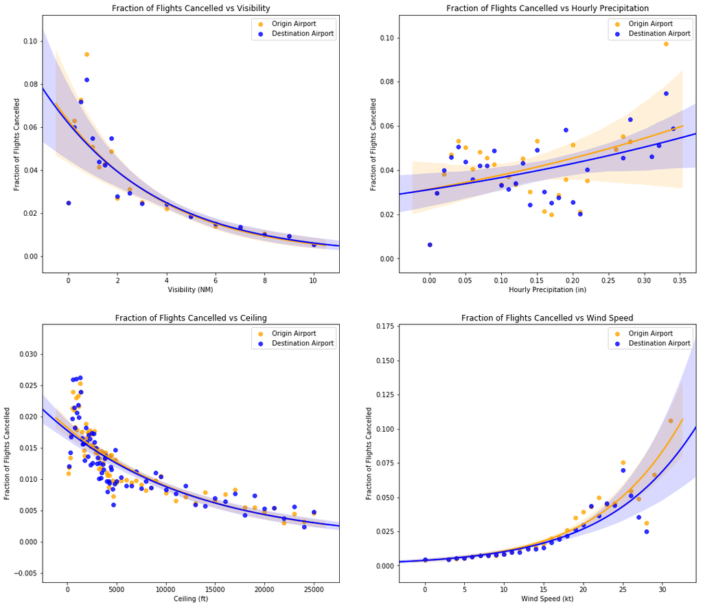

### Modeling

The first models I created attempted to predict whether a particular flight would be cancelled or not. First, I one-hot encoded the categorical columns of AIRLINE, ORIGIN_AIRPORT, and ARRIVAL_AIRPORT. Then I split the dataframe into a training subset and a testing subset because I want to avoid overfitting the model to just the training data and provide an independent dataset I can test against that the model has never seen before.

The best model was an XGBoost random forest model which had a precision of 0.84 and a recall of 0.11. Increasing the scale_pos_weight parameter led to a higher recall but a lower precision. Ultimately, I was reasonably satisfied with the default parameter of 1 to maximize the model's precision. In other words, I valued a low false-positive and a high false-negative rate over the inverse.

Code extracts are below. Note that, since the CANCELLED column is one-hot encoded, an output of 1 corresponds to a cancelled flight.

```python
flights_encoded = pd.concat([
    pd.get_dummies(flights_with_wxcx[['AIRLINE', 'ORIGIN_AIRPORT', 'DESTINATION_AIRPORT']]),
    flights_with_wxcx.drop(['SCHEDULED_DEPARTURE', 'AIRLINE', 'DAY_OF_WEEK', 'ORIGIN_AIRPORT',
                            'DESTINATION_AIRPORT', 'SCHEDULED_ARRIVAL', 'DEPARTURE_DELAY',
                            'DIVERTED', 'ARRIVAL_DELAY'], axis=1)], axis=1)

from sklearn.model_selection import train_test_split
X_train, X_test, y_train, y_test = train_test_split(flights_encoded.drop('CANCELLED', axis=1),
                                                    flights_encoded['CANCELLED'], test_size=0.33, random_state=42)

import xgboost
xgb_model = xgboost.XGBClassifier(max_depth=15, n_estimators=400, n_jobs=4, scale_pos_weight=1).fit(X_train, y_train)
y_pred_xgb = xgb_model.predict(X_test)

from sklearn.metrics import classification_report, confusion_matrix
print(classification_report(y_test, y_pred_xgb))
print(confusion_matrix(y_test, y_pred_xgb))
```

```
            precision    recall  f1-score   support

       0       0.99      1.00      0.99    677373
       1       0.84      0.11      0.19     10597

   micro avg       0.99      0.99      0.99    687970

   macro avg       0.91      0.55      0.59    687970

weighted avg       0.98      0.99      0.98    687970

[[677153    220]
 [  9448   1149]]
```